# SDL_R_Survival01

Delin Sun

8/28/2020

## Introduction

Survival analyses of the NMF outputs (10 component solution by Viraj) of cortical thickness data from NCANDA binge drinking project

Delin Sun Version date 08/04/2020.

### Independent Variables

####Drinking_class Severity of drinking problem. 0 = no/to low drinkers, 1 = medium drinkers, 2= heavy drinkers, 3 = heavy drinker + binge. We can also combine 2 and 3 as heavy drinking.

####Age_d The difference between a subject’s age at each scan and their mean age across individual timepoints (i.e. scan_age - subject_mean_age).

####Age_m The difference between a subject’s mean age across visits and the mean age of the entire sample across timepoints (i.e. subject_mean_age - mean(subject_mean_age)), thus centering cohort age at the sample mean. Each participant’s cohort age remained constant across timepoints.

####Life_trauma_RP Cumulative trauma at baseline. It was quantified as the sum of reported DSM-IV or 5 Criterion A traumatic events on the PTSD section of the Semi-Structured Assessment for the Genetics of Alcoholism (Pierucci-Lagha, Gelernter et al. 2005). A traumatic event was counted once if either the parent and/or youth reported an event. No participant met DSM criteria for PTSD. Its range is 0~5. We can combine 4 and 5 as a group.

####Fh_alc_density Family history of alcohol use and dependence (AUD) density. It was calculated based on the presence of AUD in first and second-degree relatives (Rice, Reich et al. 1995). Its range is 0~4.

####Ses Socio economic status quantified using the highest parental years of education of either parent (Brown, Myers et al. 1998). The range is 6~20 yrs. We can categorize 0 = 6~12 yrs (high school or less), 1 = 13~15 yrs (associate), 2 = 16 yrs (BA, BS), 3 = 16 plus yrs (masters or higher). Or we can do 0 = 6~12 yrs, 1 = 13~20 yrs.

####Race Self-identified race/ethnicity instead of “race”. Totally 3 categories: African-American/Black (AAmer), Caucasian/White (Cauc), and Other.

####Sex Male and Female.

####Subject Participant ID as a random effect variable.

## Set path and load packages

# (0.1) Data cleaning

Only employ subjects whose drinking class = 0 at baseline

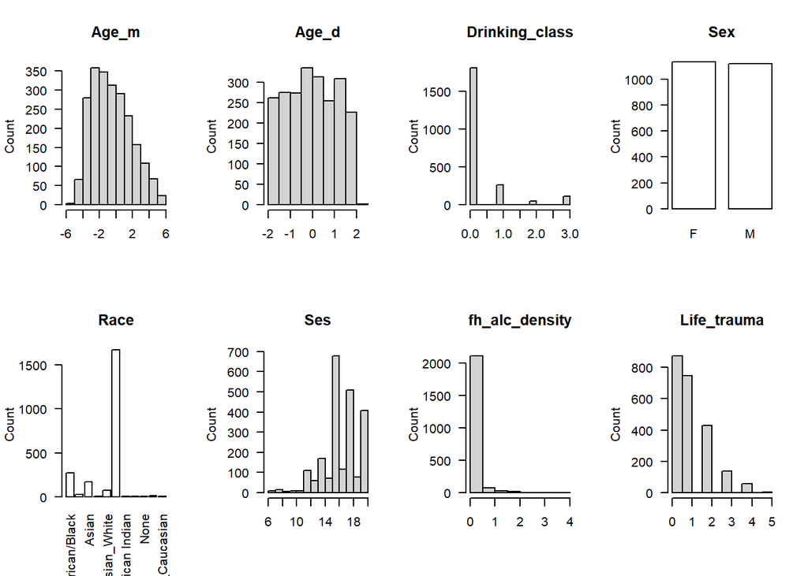

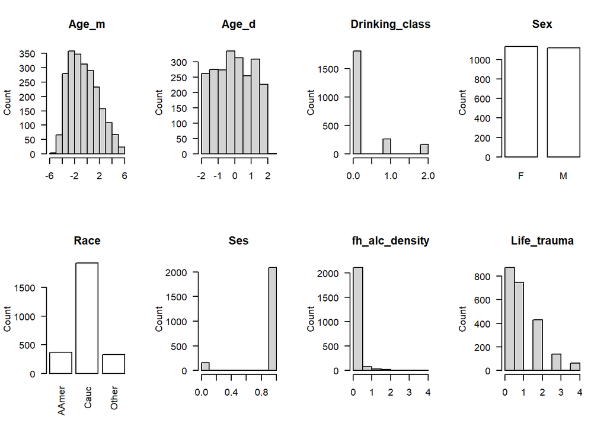

# (0.2) A Function of Data Preparation for Survival Analyses

## (0.3) Functions for statistical analyses and plots

Totally 4 functions — SDL_lm, extract models/coefficients/p values/plots for each component Already cleaned by Viraj’s Matlab scripts — SDL_heat, heatmap of p values across factors and componnets — SDL_plt, plot multiple main/interaction effects — SDL_all, call the above 3 functions

## (0.4) NMF component brain maps

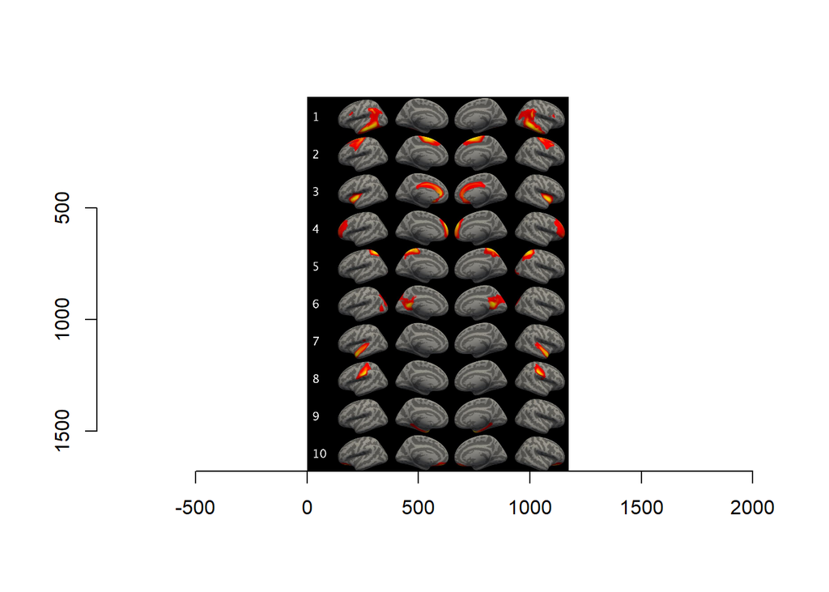

### (0.5) Residuals after removing effects of bl_age & I(bl_age^2)

# (1) Survival Analyses: raw data without bl_age

### (1.1) begins from baseline scan (N=1)

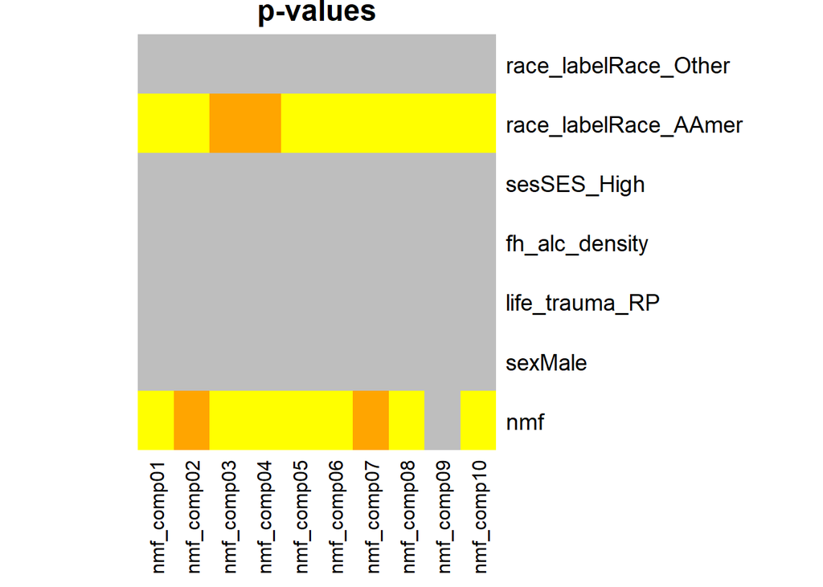

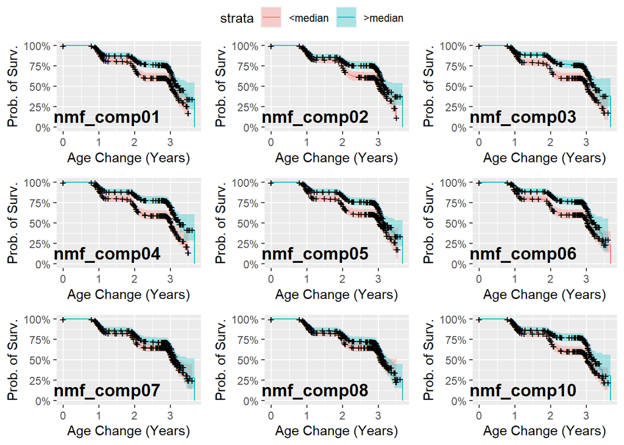

```
##                   coef exp(coef)   se(coef)          z     Pr(>|z|)
## nmf_comp01 -0.04772825 0.9533928 0.01030141 -4.6331789 3.600931e-06
## nmf_comp02 -0.03477481 0.9658229 0.01269528 -2.7391919 6.159040e-03
## nmf_comp03 -0.06844387 0.9338459 0.01518863 -4.5062565 6.598132e-06
## nmf_comp04 -0.06249627 0.9394166 0.01158019 -5.3968248 6.783056e-08
## nmf_comp05 -0.05761620 0.9440122 0.01234592 -4.6668210 3.058956e-06
## nmf_comp06 -0.08343730 0.9199488 0.01432706 -5.8237552 5.753984e-09
## nmf_comp07 -0.04091856 0.9599073 0.01502394 -2.7235574 6.458299e-03
## nmf_comp08 -0.05712237 0.9444785 0.01607951 -3.5524952 3.815959e-04
## nmf_comp09 -0.01747429 0.9826775 0.01798089 -0.9718253 3.311375e-01
## nmf_comp10 -0.10025055 0.9046107 0.01963104 -5.1067355 3.277721e-07
##                   p_fdr
## nmf_comp01 7.201863e-06
## nmf_comp02 7.175888e-03
## nmf_comp03 1.099689e-05
## nmf_comp04 3.391528e-07
## nmf_comp05 7.201863e-06
## nmf_comp06 5.753984e-08
## nmf_comp07 7.175888e-03
## nmf_comp08 5.451370e-04
## nmf_comp09 3.311375e-01
## nmf_comp10 1.092574e-06
```

```
##                  coef exp(coef)  se(coef)         z     Pr(>|z|)        p_fdr
## nmf_comp01 -0.9326641 0.3935040 0.2618152 -3.562300 3.676201e-04 0.0007352403
## nmf_comp02 -0.8912082 0.4101599 0.2616930 -3.405549 6.603127e-04 0.0008253909
## nmf_comp03 -0.8694883 0.4191660 0.2624747 -3.312655 9.241481e-04 0.0010268313
## nmf_comp04 -0.7890585 0.4542723 0.2633459 -2.996282 2.732936e-03 0.0027329357
## nmf_comp05 -0.9761294 0.3767666 0.2611515 -3.737789 1.856455e-04 0.0006635262
## nmf_comp06 -1.0393265 0.3536928 0.2616654 -3.971967 7.128153e-05 0.0006635262
## nmf_comp07 -0.8998264 0.4066403 0.2617083 -3.438280 5.854224e-04 0.0008253909
## nmf_comp08 -0.9736338 0.3777080 0.2617148 -3.720209 1.990579e-04 0.0006635262
## nmf_comp09 -0.9496945 0.3868592 0.2633324 -3.606447 3.104178e-04 0.0007352403
## nmf_comp10 -0.9132068 0.4012355 0.2634249 -3.466669 5.269512e-04 0.0008253909
```

### (1.2) begins from baseline scan (N=2)

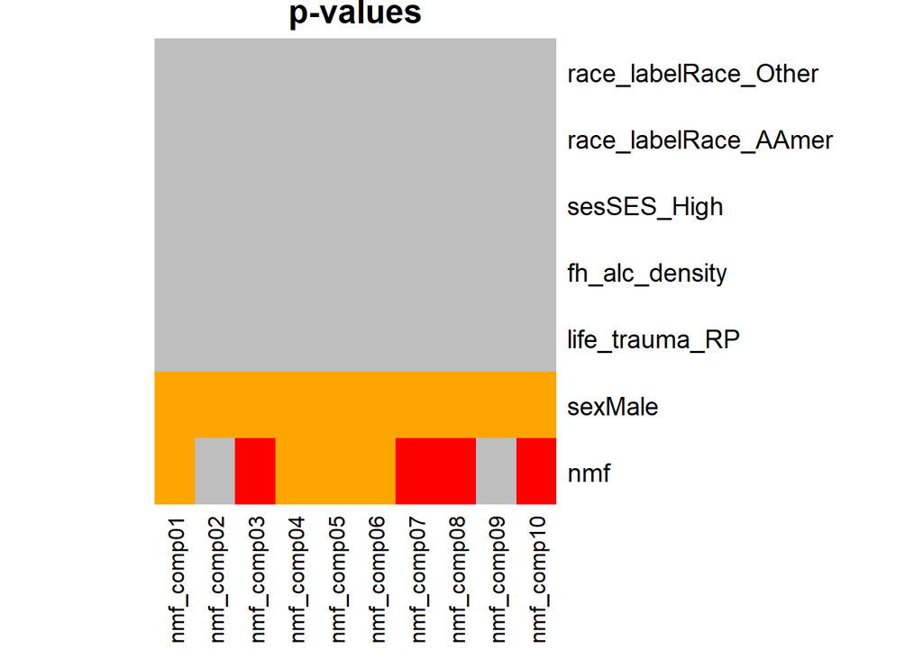

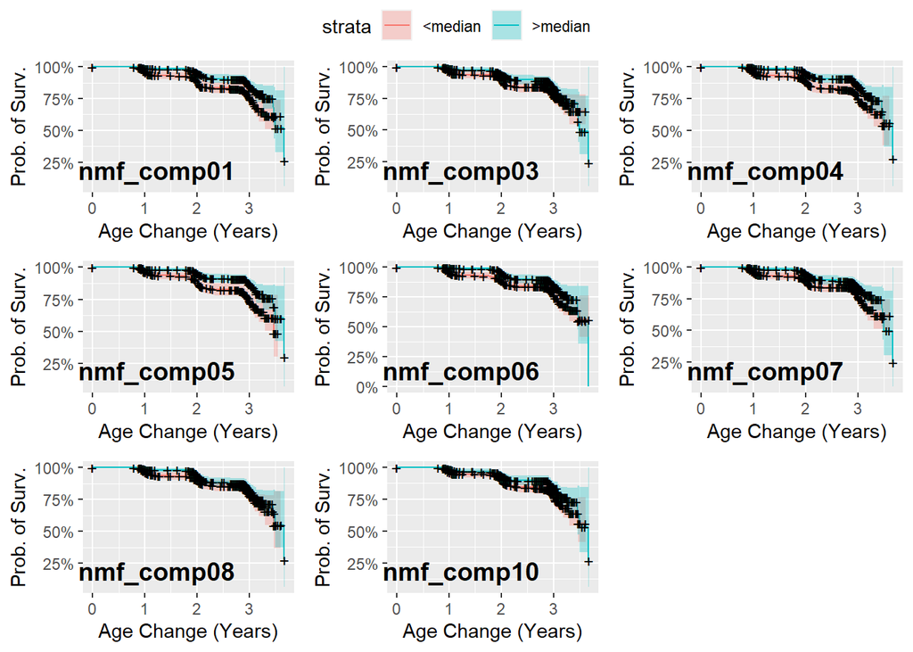

```
##                   coef exp(coef)   se(coef)         z     Pr(>|z|)       p_fdr
## nmf_comp01 -0.04676307 0.9543135 0.01515727 -3.085190 0.0020342203 0.005085551
## nmf_comp02 -0.03308763 0.9674538 0.01868579 -1.770737 0.0766044658 0.085116073
## nmf_comp03 -0.05818670 0.9434738 0.02225514 -2.614528 0.0089350739 0.014891790
## nmf_comp04 -0.05889899 0.9428020 0.01690374 -3.484377 0.0004932846 0.002466423
## nmf_comp05 -0.05998168 0.9417818 0.01814011 -3.306577 0.0009444334 0.003148111
## nmf_comp06 -0.07509636 0.9276541 0.02043102 -3.675605 0.0002372868 0.002372868
## nmf_comp07 -0.04940871 0.9517920 0.02221114 -2.224502 0.0261147076 0.032643384
## nmf_comp08 -0.05411601 0.9473222 0.02330989 -2.321590 0.0202550301 0.028935757
## nmf_comp09 -0.03405536 0.9665180 0.02673239 -1.273936 0.2026859402 0.202685940
## nmf_comp10 -0.07467195 0.9280479 0.02837557 -2.631557 0.0084994503 0.014891790
```

```
##                 coef exp(coef)  se(coef)        z     Pr(>|z|)       p_fdr
## nmf_comp01 0.6658076  1.946061 0.1986324 3.351959 0.0008024191 0.001714380
## nmf_comp02 0.6061998  1.833451 0.1993348 3.041114 0.0023570469 0.002357047
## nmf_comp03 0.6896382  1.992994 0.1996825 3.453673 0.0005530065 0.001714380
## nmf_comp04 0.6741713  1.962406 0.1986717 3.393393 0.0006903246 0.001714380
## nmf_comp05 0.6063883  1.833796 0.1986653 3.052311 0.0022708701 0.002357047
## nmf_comp06 0.7010568  2.015882 0.1991229 3.520725 0.0004303694 0.001714380
## nmf_comp07 0.6518334  1.919056 0.1987592 3.279514 0.0010398612 0.001714380
## nmf_comp08 0.6264441  1.870946 0.1986757 3.153099 0.0016154685 0.002019336
## nmf_comp09 0.6493664  1.914328 0.1991612 3.260506 0.0011121349 0.001714380
## nmf_comp10 0.6434106  1.902960 0.1986532 3.238864 0.0012000660 0.001714380
```

# (2) Survival Analyses: raw data with bl_age as covariate

### (2.1) begins from baseline scan (N=1)

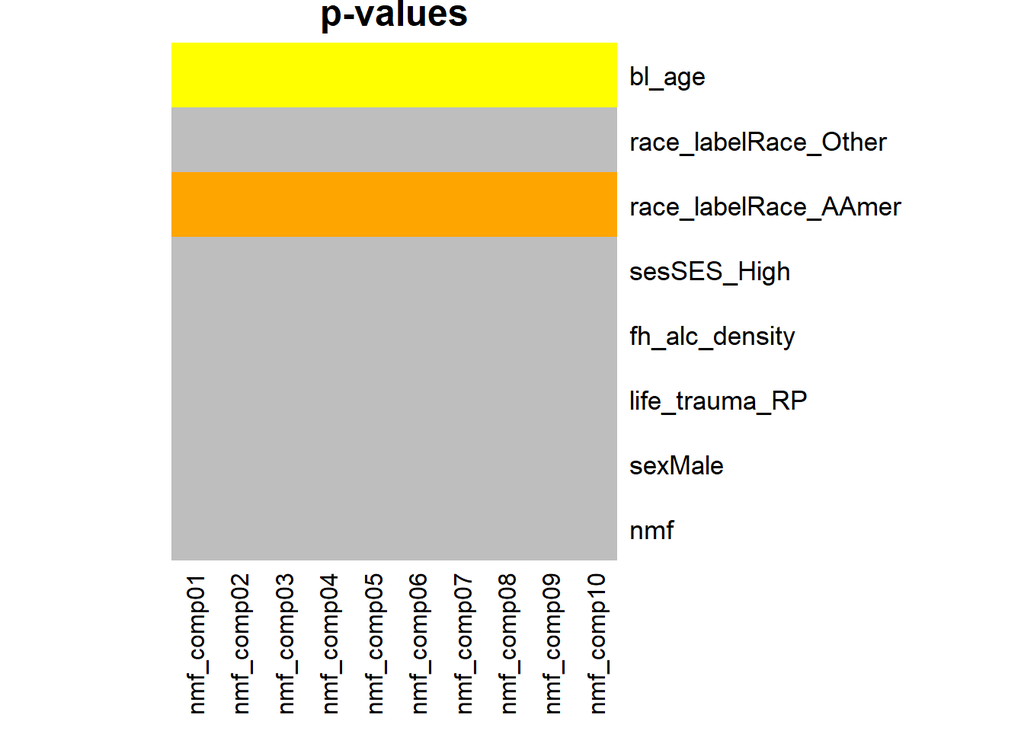

```
## [1] "NS: nmf"
```

```
##                    coef exp(coef)   se(coef)          z  Pr(>|z|)     p_fdr
## nmf_comp01  0.003546988 1.0035533 0.01160850  0.3055510 0.7599465 0.7599465
## nmf_comp02  0.003958241 1.0039661 0.01288891  0.3071044 0.7587639 0.7599465
## nmf_comp03  0.012811134 1.0128935 0.01791394  0.7151489 0.4745170 0.7599465
## nmf_comp04 -0.011643495 0.9884240 0.01292369 -0.9009417 0.3676193 0.7599465
## nmf_comp05 -0.005869399 0.9941478 0.01348366 -0.4352973 0.6633467 0.7599465
## nmf_comp06 -0.012035305 0.9880368 0.01648412 -0.7301153 0.4653197 0.7599465
## nmf_comp07  0.013063978 1.0131497 0.01596722  0.8181750 0.4132573 0.7599465
## nmf_comp08  0.008426138 1.0084617 0.01725772  0.4882532 0.6253705 0.7599465
## nmf_comp09  0.021280004 1.0215080 0.01847896  1.1515800 0.2494937 0.7599465
## nmf_comp10 -0.017557821 0.9825954 0.02175062 -0.8072331 0.4195322 0.7599465
```

```
##                 coef exp(coef)   se(coef)        z     Pr(>|z|)        p_fdr
## nmf_comp01 0.2726504  1.313441 0.03093866 8.812610 1.222653e-18 2.029960e-18
## nmf_comp02 0.2705316  1.310661 0.02811307 9.622982 6.394996e-22 3.197498e-21
## nmf_comp03 0.2798391  1.322917 0.03155441 8.868463 7.416230e-19 1.483246e-18
## nmf_comp04 0.2553142  1.290867 0.03034168 8.414635 3.941204e-17 4.379116e-17
## nmf_comp05 0.2623025  1.299920 0.02982151 8.795749 1.420972e-18 2.029960e-18
## nmf_comp06 0.2558149  1.291514 0.03162200 8.089774 5.977552e-16 5.977552e-16
## nmf_comp07 0.2770437  1.319224 0.02909589 9.521747 1.702912e-21 5.676372e-21
## nmf_comp08 0.2739804  1.315189 0.02955075 9.271521 1.835108e-20 4.587769e-20
## nmf_comp09 0.2760086  1.317859 0.02786288 9.905960 3.921842e-23 3.921842e-22
## nmf_comp10 0.2567864  1.292769 0.03018766 8.506337 1.795139e-17 2.243924e-17
```

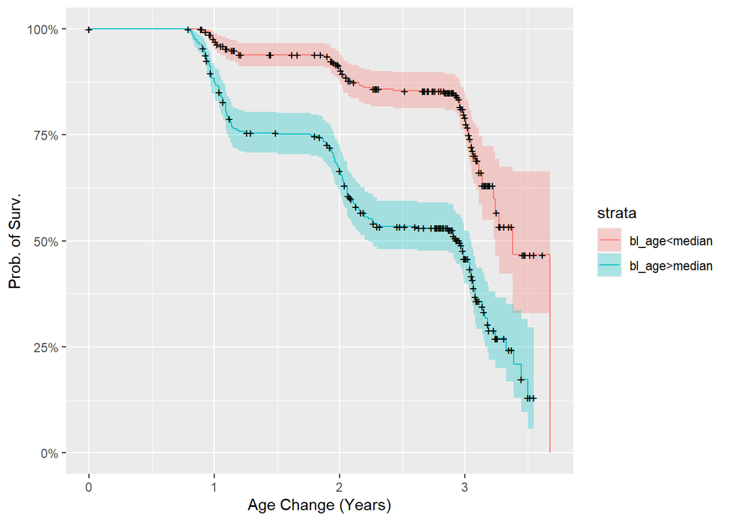

```
##                  coef exp(coef)  se(coef)         z     Pr(>|z|)       p_fdr
## nmf_comp01 -0.8725907 0.4178676 0.2631714 -3.315675 0.0009142216 0.001267834
## nmf_comp02 -0.8779675 0.4156268 0.2636595 -3.329930 0.0008686788 0.001267834
## nmf_comp03 -0.8836345 0.4132781 0.2635498 -3.352818 0.0007999324 0.001267834
## nmf_comp04 -0.8474554 0.4285039 0.2647346 -3.201151 0.0013687966 0.001368797
## nmf_comp05 -0.8764795 0.4162457 0.2631126 -3.331195 0.0008647391 0.001267834
## nmf_comp06 -0.8886253 0.4112207 0.2637605 -3.369062 0.0007542456 0.001267834
## nmf_comp07 -0.8791380 0.4151406 0.2633457 -3.338342 0.0008427984 0.001267834
## nmf_comp08 -0.8662231 0.4205369 0.2635670 -3.286539 0.0010142672 0.001267834
## nmf_comp09 -0.8472384 0.4285969 0.2640599 -3.208508 0.0013342545 0.001368797
## nmf_comp10 -0.8682324 0.4196927 0.2635085 -3.294894 0.0009845892 0.001267834
```

### (2.2) begins from baseline scan (N=2)

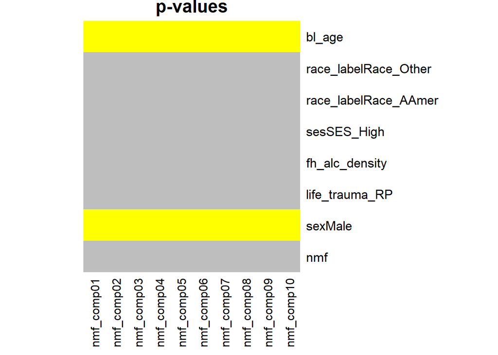

```
## [1] "NS: nmf"
```

```
##                    coef exp(coef)   se(coef)           z  Pr(>|z|)     p_fdr
## nmf_comp01  0.003463127 1.0034691 0.01730325  0.20014321 0.8413686 0.9391019
## nmf_comp02  0.005662935 1.0056790 0.01894849  0.29885948 0.7650473 0.9391019
## nmf_comp03  0.021741069 1.0219791 0.02624413  0.82841648 0.4074347 0.9391019
## nmf_comp04 -0.008198393 0.9918351 0.01911751 -0.42884207 0.6680382 0.9391019
## nmf_comp05 -0.009468818 0.9905759 0.01991469 -0.47546913 0.6344526 0.9391019
## nmf_comp06 -0.003661183 0.9963455 0.02381340 -0.15374465 0.8778111 0.9391019
## nmf_comp07  0.002454203 1.0024572 0.02371564  0.10348457 0.9175784 0.9391019
## nmf_comp08  0.010207620 1.0102599 0.02502121  0.40795863 0.6833041 0.9391019
## nmf_comp09 -0.002106825 0.9978954 0.02757671 -0.07639869 0.9391019 0.9391019
## nmf_comp10  0.009021447 1.0090623 0.03164645  0.28506979 0.7755907 0.9391019
```

```
##                 coef exp(coef)   se(coef)        z     Pr(>|z|)        p_fdr
## nmf_comp01 0.2493488  1.283189 0.04512654 5.525546 3.284621e-08 4.692316e-08
## nmf_comp02 0.2485708  1.282192 0.04066624 6.112459 9.810732e-10 4.905366e-09
## nmf_comp03 0.2649245  1.303333 0.04555575 5.815390 6.049284e-09 1.209857e-08
## nmf_comp04 0.2352448  1.265218 0.04440427 5.297797 1.172082e-07 1.302313e-07
## nmf_comp05 0.2350634  1.264989 0.04353539 5.399365 6.687733e-08 8.359666e-08
## nmf_comp06 0.2406493  1.272075 0.04648290 5.177158 2.252915e-07 2.252915e-07
## nmf_comp07 0.2463505  1.279348 0.04194899 5.872620 4.289615e-09 1.072404e-08
## nmf_comp08 0.2523542  1.287052 0.04290937 5.881097 4.075564e-09 1.072404e-08
## nmf_comp09 0.2439624  1.276296 0.03951151 6.174463 6.638864e-10 4.905366e-09
## nmf_comp10 0.2504829  1.284646 0.04363150 5.740874 9.418923e-09 1.569820e-08
```

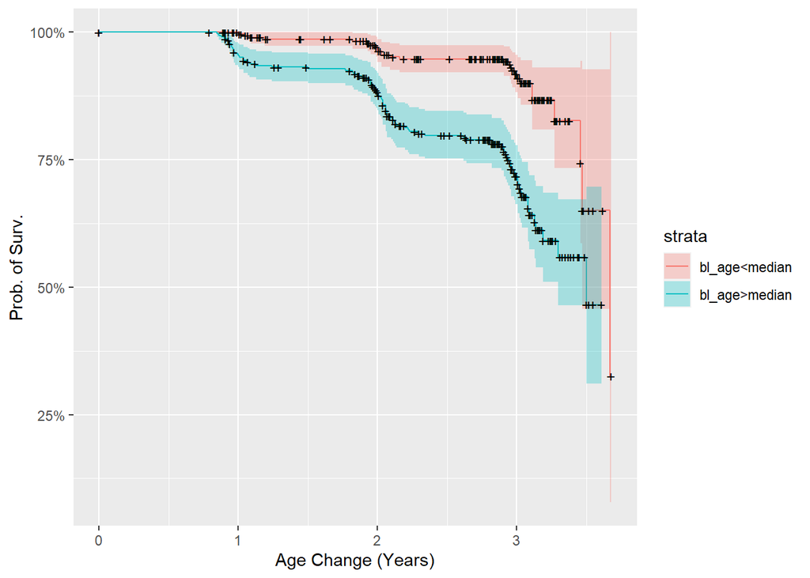

```
##                 coef exp(coef)  se(coef)        z     Pr(>|z|)        p_fdr
## nmf_comp01 0.7259437  2.066680 0.1991306 3.645565 0.0002668051 0.0003335064
## nmf_comp02 0.7320226  2.079282 0.2001748 3.656917 0.0002552674 0.0003335064
## nmf_comp03 0.7131259  2.040359 0.1997967 3.569258 0.0003579932 0.0003579932
## nmf_comp04 0.7271455  2.069166 0.1989965 3.654062 0.0002581239 0.0003335064
## nmf_comp05 0.7173250  2.048945 0.1998516 3.589288 0.0003315818 0.0003579932
## nmf_comp06 0.7271143  2.069101 0.1991774 3.650586 0.0002616424 0.0003335064
## nmf_comp07 0.7259791  2.066754 0.1991092 3.646135 0.0002662137 0.0003335064
## nmf_comp08 0.7325712  2.080423 0.1998180 3.666192 0.0002461894 0.0003335064
## nmf_comp09 0.7265963  2.068030 0.1992157 3.647284 0.0002650272 0.0003335064
## nmf_comp10 0.7264157  2.067656 0.1991315 3.647920 0.0002643718 0.0003335064
```

# (3) Survival Analyses: residuals after regressing out bl_age and I(bl_age^2)

### (3.1) begins from baseline scan (N=1)

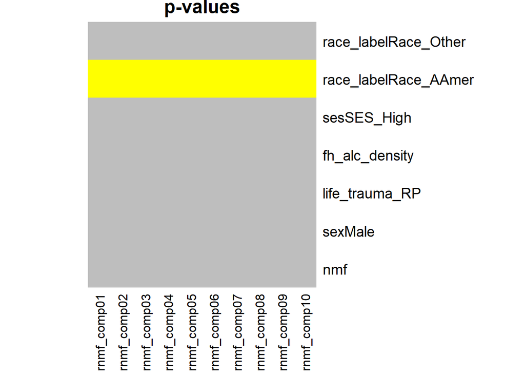

```
## [1] "NS: nmf"
```

```
##                    coef exp(coef)   se(coef)           z  Pr(>|z|)     p_fdr
## nmf_comp01 -0.001348808 0.9986521 0.01200665 -0.11233841 0.9105551 0.9294333
## nmf_comp02  0.001207191 1.0012079 0.01363167  0.08855788 0.9294333 0.9294333
## nmf_comp03  0.010647651 1.0107045 0.01824405  0.58362326 0.5594738 0.9294333
## nmf_comp04 -0.011522343 0.9885438 0.01332296 -0.86484884 0.3871218 0.9294333
## nmf_comp05 -0.010895060 0.9891641 0.01385184 -0.78654264 0.4315496 0.9294333
## nmf_comp06 -0.019418077 0.9807692 0.01698885 -1.14298958 0.2530429 0.9294333
## nmf_comp07  0.002747512 1.0027513 0.01589617  0.17284115 0.8627763 0.9294333
## nmf_comp08 -0.004677215 0.9953337 0.01772388 -0.26389334 0.7918621 0.9294333
## nmf_comp09  0.006742107 1.0067649 0.01839375  0.36654346 0.7139596 0.9294333
## nmf_comp10 -0.021672249 0.9785609 0.02178058 -0.99502649 0.3197234 0.9294333
```

```
##                  coef exp(coef)  se(coef)         z     Pr(>|z|)        p_fdr
## nmf_comp01 -0.9205074 0.3983169 0.2616319 -3.518330 0.0004342715 0.0005443183
## nmf_comp02 -0.9201192 0.3984715 0.2615752 -3.517608 0.0004354547 0.0005443183
## nmf_comp03 -0.9241513 0.3968681 0.2614775 -3.534343 0.0004087904 0.0005443183
## nmf_comp04 -0.9002208 0.4064799 0.2623861 -3.430902 0.0006015781 0.0006015781
## nmf_comp05 -0.9349499 0.3926055 0.2620280 -3.568130 0.0003595377 0.0005443183
## nmf_comp06 -0.9552594 0.3847124 0.2631074 -3.630682 0.0002826728 0.0005443183
## nmf_comp07 -0.9199518 0.3985383 0.2614533 -3.518609 0.0004338161 0.0005443183
## nmf_comp08 -0.9251776 0.3964610 0.2623349 -3.526703 0.0004207677 0.0005443183
## nmf_comp09 -0.9075268 0.4035210 0.2634183 -3.445193 0.0005706519 0.0006015781
## nmf_comp10 -0.9217968 0.3978036 0.2617492 -3.521680 0.0004288221 0.0005443183
```

### (3.2) begins from baseline scan (N=2)

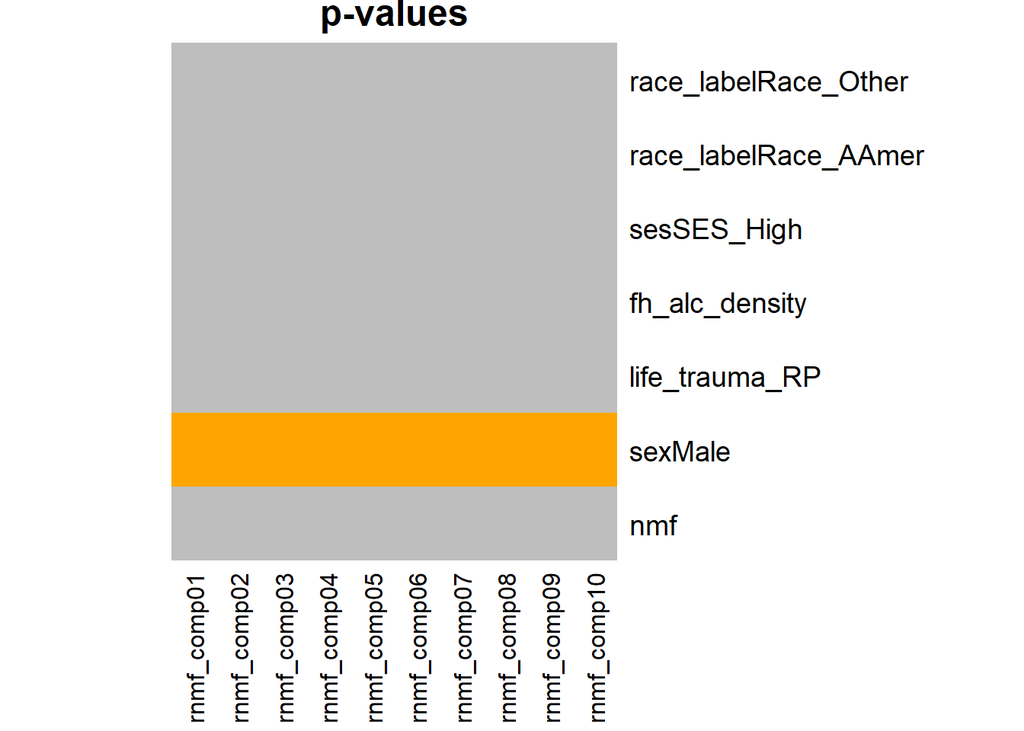

```
## [1] "NS: nmf"
```

```
##                     coef exp(coef)   se(coef)           z  Pr(>|z|)    p_fdr
## nmf_comp01 -0.0030167157 0.9969878 0.01777459 -0.16972066 0.8652298 0.985711
## nmf_comp02  0.0003587168 1.0003588 0.02002936  0.01790955 0.9857110 0.985711
## nmf_comp03  0.0207152774 1.0209313 0.02696651  0.76818531 0.4423771 0.985711
## nmf_comp04 -0.0109075802 0.9891517 0.01965736 -0.55488543 0.5789730 0.985711
## nmf_comp05 -0.0168463997 0.9832947 0.02044571 -0.82395787 0.4099635 0.985711
## nmf_comp06 -0.0167785052 0.9833615 0.02496975 -0.67195332 0.5016134 0.985711
## nmf_comp07 -0.0096180074 0.9904281 0.02371781 -0.40551829 0.6850966 0.985711
## nmf_comp08 -0.0063079924 0.9937119 0.02596437 -0.24294804 0.8080456 0.985711
## nmf_comp09 -0.0118054342 0.9882640 0.02731525 -0.43219200 0.6656019 0.985711
## nmf_comp10  0.0027870156 1.0027909 0.03175306  0.08777156 0.9300582 0.985711
```

```
##                 coef exp(coef)  se(coef)        z    Pr(>|z|)       p_fdr
## nmf_comp01 0.6400017  1.896484 0.1990040 3.216024 0.001299799 0.001727309
## nmf_comp02 0.6397300  1.895969 0.2005566 3.189773 0.001423844 0.001727309
## nmf_comp03 0.6281421  1.874125 0.1995941 3.147098 0.001648997 0.001727309
## nmf_comp04 0.6429295  1.902045 0.1989948 3.230887 0.001234068 0.001727309
## nmf_comp05 0.6254023  1.868998 0.1995854 3.133507 0.001727309 0.001727309
## nmf_comp06 0.6484661  1.912605 0.1993769 3.252463 0.001144096 0.001727309
## nmf_comp07 0.6397634  1.896032 0.1989378 3.215896 0.001300380 0.001727309
## nmf_comp08 0.6366453  1.890129 0.1992489 3.195226 0.001397212 0.001727309
## nmf_comp09 0.6418182  1.899932 0.1990842 3.223853 0.001264782 0.001727309
## nmf_comp10 0.6394558  1.895449 0.1990138 3.213123 0.001313000 0.001727309
```